# Distribution of Heavy Cardboard top 50 data

```r
source("hc.R")
```

The first thing I plotted with a graph of votes for each game, just to get a sense of the data. What’s noticeable here is the huge gap between the two top games and the rest.

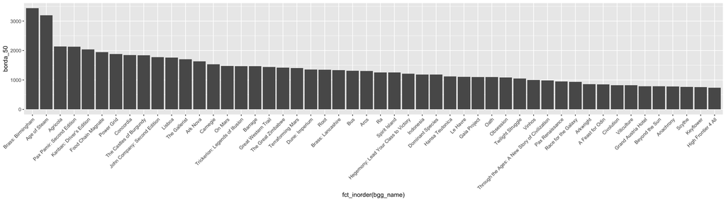

```r
herd_top_50_games |>
  ggplot(aes(fct_inorder(bgg_name), borda_50)) +
  geom_col() +
  theme(axis.text.x = element_text(angle = 45, hjust = 1,vjust = 1))
```

## Distributions of rankings for games in top 50

One of the first things I like to do with a dataset is get a sense of the overall distributions of the data. In this case I was interested in the distributions of the rankings for the top 50 games. To do this I plotted a histogram of rankings for each game with a bin-width of 5.

For those not familiar with histograms, this is essentially a bar chart that shows for each game, how many rankings fell in each bin So in the graph below we can see that nearly 40 people ranked Brass Birmingham and Age of Steam in their top 5, while no other game had more than 20 top-5 rankings.

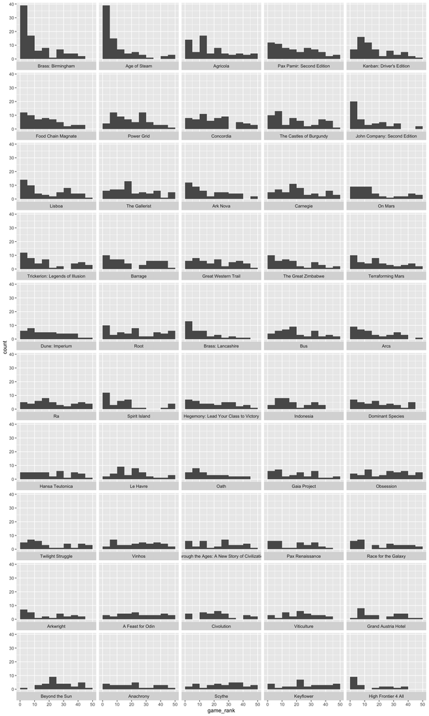

```r
herd_top50_rankings |>
  ggplot(aes(game_rank)) +
  geom_histogram(breaks = seq(0,50,by= 5)) +
  facet_wrap(~fct_inorder(bgg_name), ncol=5, strip.position = "bottom")
```

Another way to look at disbibutions is a strip chart. A lot of people find a strip chart easier to interpret. With a strip chart we plot each ranking individually. We add a little vertical jitter so we can see when several points overlap.

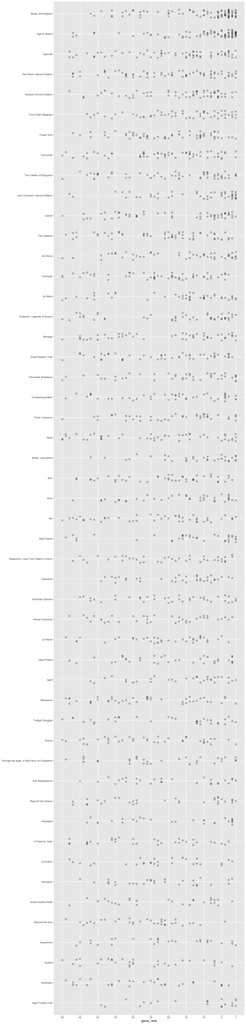

```r
herd_top50_rankings |>
  arrange(desc(herd_rank)) |>
  ggplot(aes(game_rank, fct_inorder(bgg_name))) +
  geom_jitter(height=0.2, width=0, size = 2, shape = 1) +
  scale_x_reverse(limits = c(50,1), breaks = c(1, 5, 10, 15, 20, 25, 30, 35, 40, 45, 50), minor_breaks=NULL) +
  labs(y=NULL)
```